# The Title is Not Decided Yet….

Group 14

## II. Analysis Part 1 (Time??)

### War & Peace

We acquainted ourselves with the dataset by exploring two important key words: **war** and **peace**. After processing the text data into the Term Document Matrix (TDM), we were able to find word associations. The top terms correlated with **war** were *enemi*, *forc*, *shoot*, *air*, and *armi*. The top term associated with **peace** was *needfor*. In addition to finding associations in the TDM, we plotted the frequency of these words sequentially to get a sense of how the SOTU speeches have evolved over time. Our visualizations indicate peaks around the 150th SOTU speech, which was during the time of World War II, which lasted from 1939 to 1945. We see a peak in the frequency of the word **peace** just before WWII begins, and a peak in the word **war** a couple of years later. Placing these bar charts in context of larger world events shows the power of a simple visualization in telling a story.

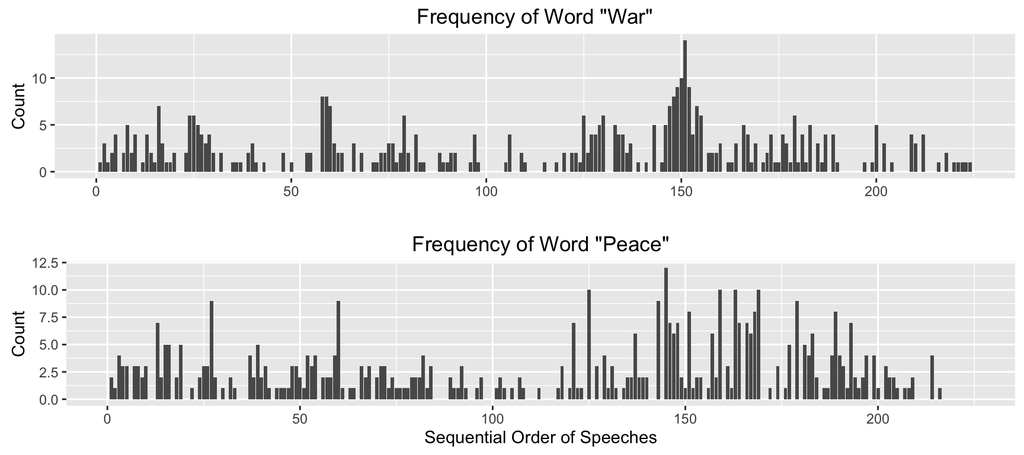

### Our Pronouns, Ourselves

In this section, we continue the use of temporal analysis, turning from the broad subjects of **war** and **peace** to a more meta-analytical look at how Presidents refer to themselves, the country, and the citizens thereof. Before examining the data, we hypothesized that there might be an increase in instances of first-person singular prounoun (“I”,“me”,“my”,“mine”) usage; as the role of the United States presidency became an increasingly powerful position, perhaps those who held the office would insert themselves more frequently into their States of the Union addresses.

Interestingly, the trend we see shows that while first-person singular prounoun usage has indeed increased in the past century, it has been greatly over-shadowed by the use of the first-person *plural* prounoun (“we”,“us”,“our”,“ours”). The trend is abundantly clear and persistent over the last 100 years.

One might speculate that, with the advent of broadcast radio in the early 20th century (and later, television), the nature of the predsient’s annual State of the Union address transformed from a mere “status report” to a unifiying, morale-boosting, identity-forging speech.

Further interesting analysis along these lines might include noting differences in prounoun usage in election years vs. non-election years for 1st-term presidents.

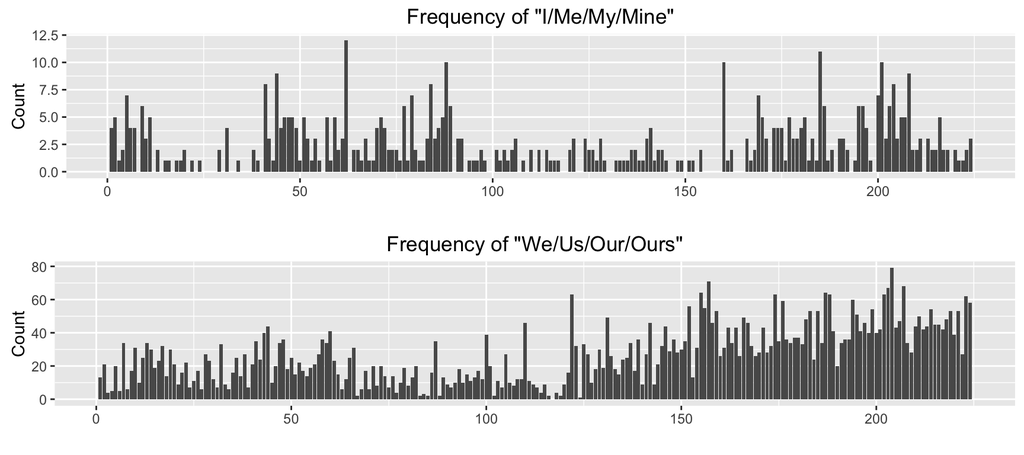

Similar to the above two plots, here we examine the relative usage of the pronouns “you” and “they”. While neither is wholly remarkable, what becomes very interesting to investigate are the anomalies in frequency. For example, on the “You” plot below, we see one State of the Union Address, number 175 (Lyndon B. Johnson, 1966), where the frequency of “you” explodes.

In this speech, Johnson employs the following structural style:

> I recommend that you provide…

and

> I recommend that you make it possible …

and

> I recommend that you meet the growing menace of crime …

This makes it seem conversational – he is asking his listeners (the American people as well as the legislature) for help in accomplishing a list of goals. It also casts him in a very passive, almost non-threatening light. He is presenting himself as a public servant, and not as a domineering leader. Eventually, he summarizes his pleas with this eloquent paragraph:

> I have not come here tonight to ask for pleasant luxuries or for idle  
> pleasures. I have come here to recommend that you, the representatives  
> of the richest Nation on earth, you, the elected servants of a people  
> who live in abundance unmatched on this globe, you bring the most urgent decencies of life to all of your fellow Americans.

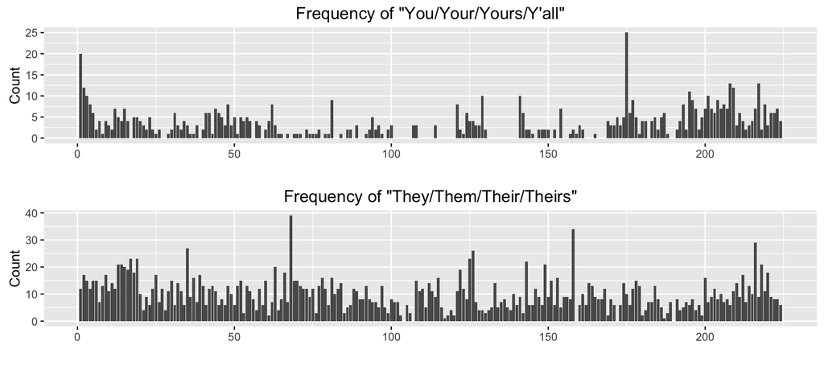

Here, we see the relative usage of the following groups of terms: (“country/nation”) and (“America/American”). The most obvious observation is that, within the last 50 years, presidents have been using “America(n)” far more frequently.

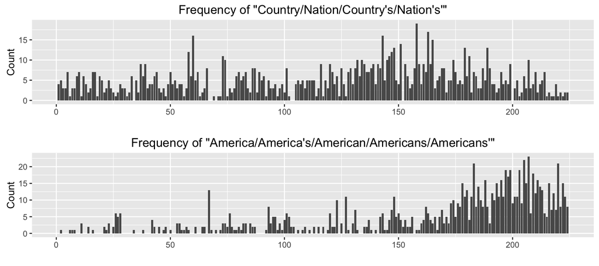

## III. Topic Analysis

In this part, we did topic analysis over the speeches of presidents using LDA. We first discovered the possible five topics among all speeches. Each speech will be assigned to a topic. The related words of each topic will aslo show in the legend of each plot. We then discovered the topics of speeches for both Republican and Democrat presidents. We expect some differences between the topics for different parties.

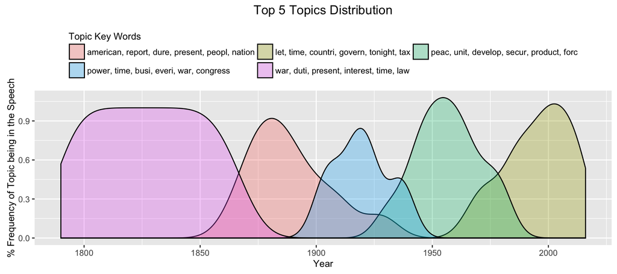

Next, we would like to study the topics in the State of the Union speech texts by party and try to discover the difference between the Republican and Democratic leaders.

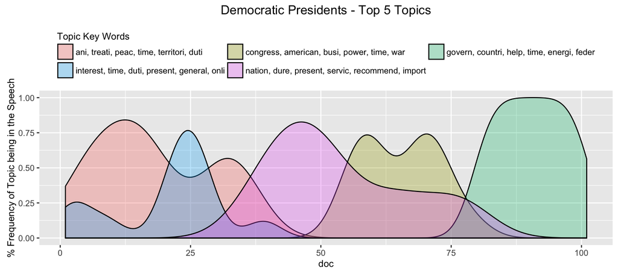

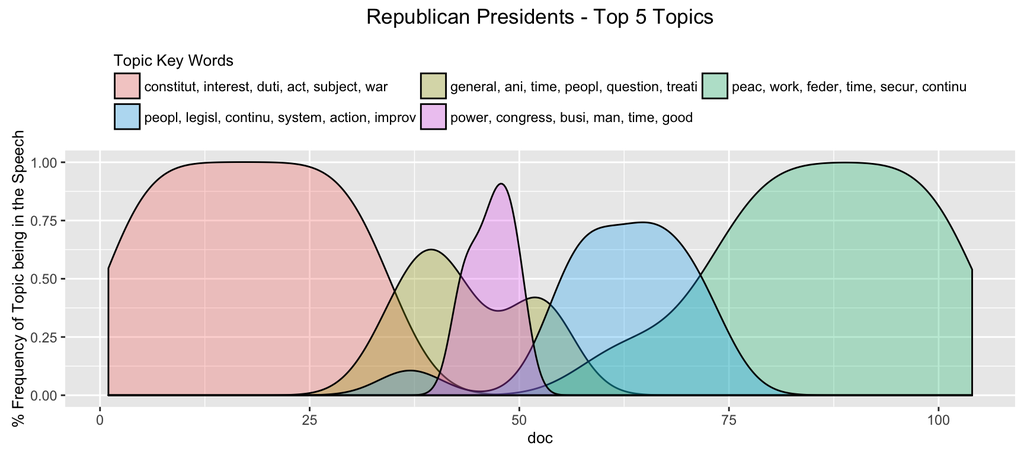

## IV. Personality Analysis for 6 Presidents

In this part, we select 6 presidents and study their personalities based on the Personality Insights analysis from IBM Watson. We not only want to compare different individual presidents’ personalities, but also would like to see the time/generation difference. So we picked the presidents in two groups: those before the 1940s and those after the 1990s. We would like to compare if the presidents demonstrate strong personality differences through their State of the Union speeches, and if the presidents from different times tend to show some common features. So we choose George Washington, Thomas Jefferson, Franklin D. Roosevelt, William J. Clinton, George W. Bush and Barack Obama.

The IBM Watson Personality Insights takes people’s writing text as input and gives analysis about personality Big 5, Values, and Needs as the output. The analysis works well on text with more than 3,500 words. For each president, we combine all his State of the Union speech documents into one. Hence we have large enough corpus for each president to get very strong analysis results from the application.

We use most of the analysis results in our visualization. Let’s first look at the definitions for the categories. We quote the official definition form IBM Watson here (http://www.ibm.com/smarterplanet/us/en/ibmwatson/developercloud/doc/personality-insights/basics.shtml):

- **Big Five** personality characteristics represent the most widely used model for generally describing how a person engages with the world. The model includes five primary characteristics, or dimensions:
  - Agreeableness is a person’s tendency to be compassionate and cooperative toward others.
  - Conscientiousness is a person’s tendency to act in an organized or thoughtful way.
  - Extraversion is a person’s tendency to seek stimulation in the company of others.
  - Emotional Range, also referred to as Neuroticism or Natural Reactions, is the extent to which a person’s emotions are sensitive to the person’s environment.
  - Openness is the extent to which a person is open to experiencing a variety of activities.
- **Needs** describe which aspects of a product will resonate with a person.
- **Values** describe motivating factors that influence a person’s decision making.

We summarize all test results in the following table. The color range from dark read to dark green is corresponding to the 0% to 100% percentile.

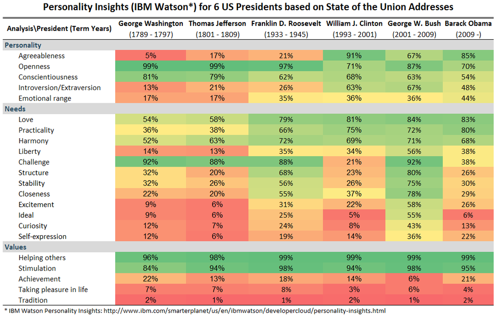

From the table we can see some obvious features. First of all, Agreeableness changes a lot over time. The 3 presidents before the 1940s tend to have very low Agreeableness comparing with the most recent ones. One of the reasons could be that the major issues the US is dealing with nowadays are very different from the early time. Presidents during war time tend to have low agreeableness. The other reason might be that the change of language usage over time affects the test results. It is possible that the Watson system’s analysis is more based on modern languages and standards. Another obvious pattern is that the analyses of Franklin Roosevelt and George W. Bush show similar patterns. We would like to point out another interesting finding: all 6 presidents reveal very similar Values. This means that the general values shown in the Union of the State speeches stay the same over time.

After interpreting the table, we visualize the information for different presidents on the following 2 radar plots. We omit the Value information here, because all 6 president show almost identical patterns for the Value analysis.

#### **Personality Insights - Big 5 Personality Percentiles for 6 Presidents**

[interactive chart not shown]

#### **Personality Insights - (Consumer) Needs Percentiles for 6 Presidents**

[interactive chart not shown]

With these plots and personality analyses, we are able to see what kind of values and personalities the presidents show through their State of the Union speeches. These may not be the same as their real personality, however, these are the interpretation of their personalities as presidents of the United States.

## V. K-Means Clustering

We use a K-Means cluster analysis to see which speeches are similar to each other and use Pricinple Component Analysis to reduce dimensions and provide a visual representation of the cluster space. It is easy to see the same early level clusters among party and era combined. Speeches made by the same president are always clustered together. Also, speeches from the same Political Party and Era are commonly next to each other (Obama & Clinton, Reagan & Bush Sr., Eisenhower & Truman).

[interactive chart not shown]

## VI. Foreign Policy

When names of countries get mentioned during the speeches, it is usually that they demand national attention which reflect the foreign policy at that time. The instances of country names point to contemporaneous events. We can see the almost isolated reference of Vietnam in the 1960s (the Vietnam War), the bubbling of “Korea” in the 1950s (the Korean War), the rise and fall of soviet between 1945 and 1991, and the rise in “Iraq,” “Iran” and “Afghanistan” mentions in recent decades.

[interactive chart not shown]

## Reference

[1] Radar Plot: http://bl.ocks.org/nbremer/6506614